# Oral Health Problems

# 1 Description of DataSchema variable

The description of harmonised variable is the following:

- Short name: `oral_problems`
- Variable label: `The participant lost all the natural teeth or uses dentures (we assume that if they wear dentures it is because they have lost the teeth)`
- Variable description: `There is different information about 'oral health' ('dental visits', 'using dentures or lost natural teeth' and 'eating problems') through the multiple studies taken into account. We have harmonised 'lose natural teeth - using dentures' and we have considered 'using dentures' as a consequence of losing all the natural teeth.`
- Domain: `Diseases`
- Value type: `categorical`
- Category coding:

| **Code** | **Category Label** |
| --- | --- |
| 0 | No |
| 1 | Yes |

- Category missings:

| **Code** | **Category Label** |
| --- | --- |
| 991 | CAPI/interviewer error |
| 992 | Impute |
| 993 | Disable to measure |
| 994 | Not attempt/not done |
| 995 | Does not answer |
| 996 | Not applicable |
| 997 | Refuse |
| 998 | Do not know |
| 999 | Missing |

# 2 Data process

## 2.1 England

### 2.1.1 Wave 1

Not found.

### 2.1.2 Wave 2

Not found.

### 2.1.3 Wave 3

#### 2.1.3.1 Study-specific variable description

| **Name** | `hedent` |
| --- | --- |
| **Label** | `Whether has own teeth` |
| **Table name** | `wave_3_elsa_data_v4` |
| **Categories** | `1 = Has no natural teeth and wears dentures` `2 = Has both natural teeth and denture(s)` `3 = Has only natural teeth` `4 = Has neither natural teeth nor dentures` |
| **Missings** | `-1 = Not applicable` `-2 = Schedule not applicable` `-8 = Don't Know` `-9 = Refusal` |
| **Description** |  |

hedent

| Sample size | Missing values |
| --- | --- |
| 9771 | 6 |

Category

|  | 1 | 2 | 3 | 4 |
| --- | --- | --- | --- | --- |
| Frequency | 1507.00 | 2683.00 | 5520.00 | 55.00 |
| Percentage | 15.42 | 27.46 | 56.49 | 0.56 |

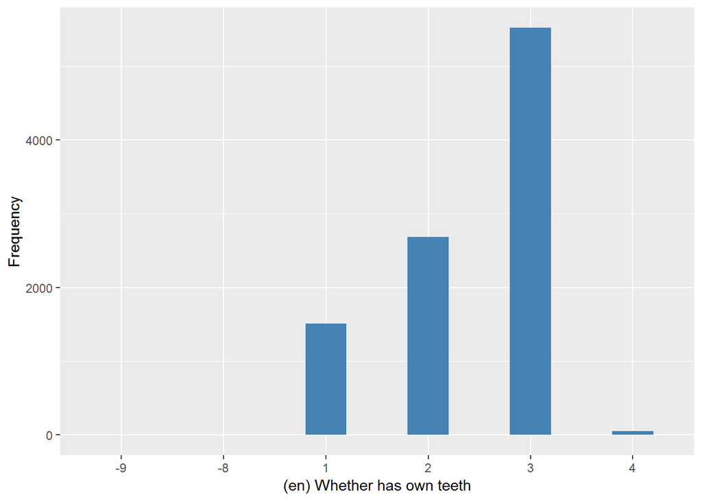

#### 2.1.3.2 Harmonisation algorithm

To compute `oral_problems` from the study-specific variable it has to be recoded as follows:

- `1,4 into 1`
- `2,3 into 0`
- `-9 into 997`
- `-8 into 998`
- `-1,-2 into 996`

**R script:**

```r
ELSA_ds_w3 <- tibble(id = ELSA_w3$id)
ELSA_ds_w3$oral_problems <- car::recode(ELSA_w3$hedent, "c(1,4) = 1; c(2,3) = 0; c(-1,-2) = 996; -9 = 997; -8 = 998 ")
```

#### 2.1.3.3 Statistical description of the new harmonised variable

The participant lost all the natural teeth or uses dentures

| Sample size | Missing values |
| --- | --- |
| 9771 | 6 |

Category

|  | 0 | 1 |
| --- | --- | --- |
| Frequency | 8203.00 | 1562.00 |
| Percentage | 83.95 | 15.99 |

Type of missing

|  | 991 | 992 | 993 | 994 | 995 | 996 | 997 | 998 | 999 | NA |
| --- | --- | --- | --- | --- | --- | --- | --- | --- | --- | --- |
| Frequency | 0 | 0 | 0 | 0 | 0 | 0 | 2.00 | 4.00 | 0 | 0 |
| Percentage | 0 | 0 | 0 | 0 | 0 | 0 | 0.02 | 0.04 | 0 | 0 |

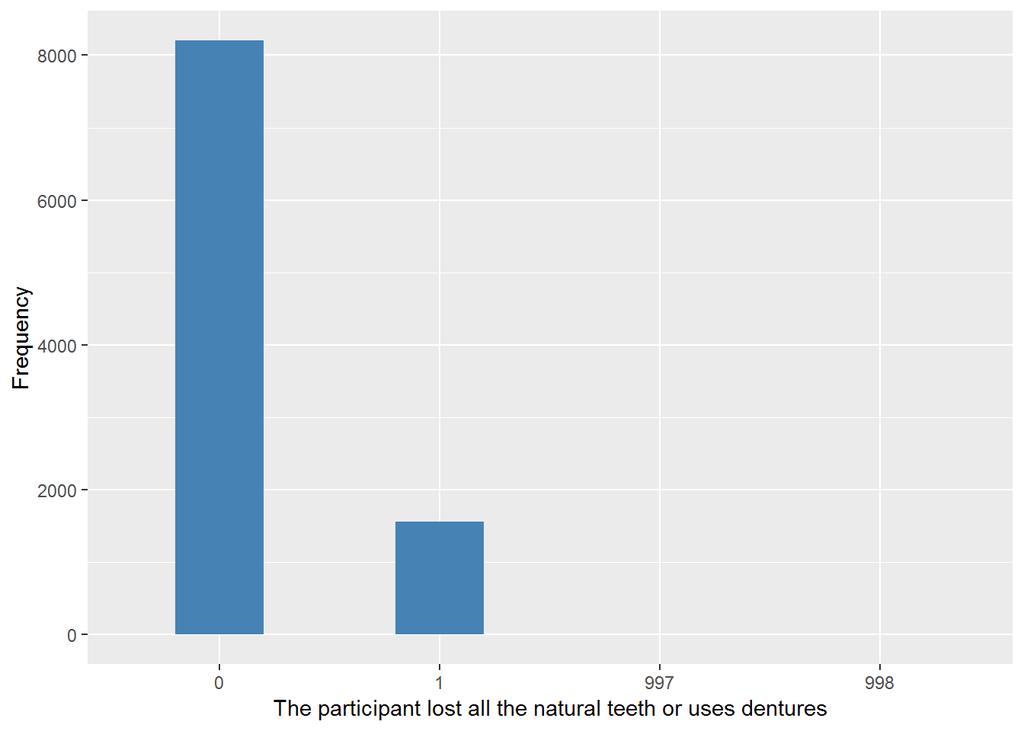

#### 2.1.3.4 Validation

### 2.1.4 Wave 4

Not found.

### 2.1.5 Wave 5

#### 2.1.5.1 Study-specific variable description

| **Name** | `hedent` |
| --- | --- |
| **Label** | `Whether has natural teeth, dentures or neither` |
| **Table name** | `wave_5_elsa_data_v4` |
| **Categories** | `1 = Has no natural teeth and wears dentures` `2 = Has both natural teeth and denture(s)` `3 = Has only natural teeth` `4 = Has neither natural teeth nor dentures` |
| **Missings** | `-1 = Not applicable` `-8 = Don't Know` `-9 = Refusal` |
| **Description** |  |

hedent

| Sample size | Missing values |
| --- | --- |
| 10274 | 11 |

Category

|  | 1 | 2 | 3 | 4 |
| --- | --- | --- | --- | --- |
| Frequency | 1316.00 | 2876.00 | 6011.00 | 60.00 |
| Percentage | 12.81 | 27.99 | 58.51 | 0.58 |

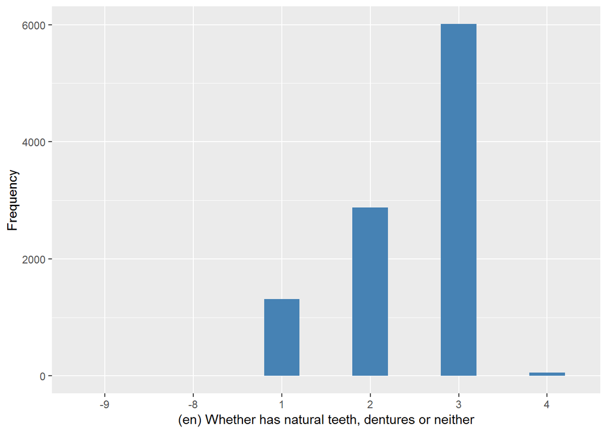

#### 2.1.5.2 Harmonisation algorithm

To compute `oral_problems` from the study-specific variable it has to be recoded as follows:

- `1,4 into 1`
- `2,3 into 0`
- `-9 into 997`
- `-8 into 998`
- `-1 into 996`

**R script:**

```r
ELSA_ds_w5 <- tibble(id = ELSA_w5$id)
ELSA_ds_w5$oral_problems <- car::recode(ELSA_w5$hedent, "c(1,4) = 1; c(2,3) = 0; c(-1) = 996; -9 = 997; -8 = 998 ")
```

#### 2.1.5.3 Statistical description of the new harmonised variable

The participant lost all the natural teeth or uses dentures

| Sample size | Missing values |
| --- | --- |
| 10274 | 11 |

Category

|  | 0 | 1 |
| --- | --- | --- |
| Frequency | 8887.0 | 1376.00 |
| Percentage | 86.5 | 13.39 |

Type of missing

|  | 991 | 992 | 993 | 994 | 995 | 996 | 997 | 998 | 999 | NA |
| --- | --- | --- | --- | --- | --- | --- | --- | --- | --- | --- |
| Frequency | 0 | 0 | 0 | 0 | 0 | 0 | 6.00 | 5.00 | 0 | 0 |
| Percentage | 0 | 0 | 0 | 0 | 0 | 0 | 0.06 | 0.05 | 0 | 0 |

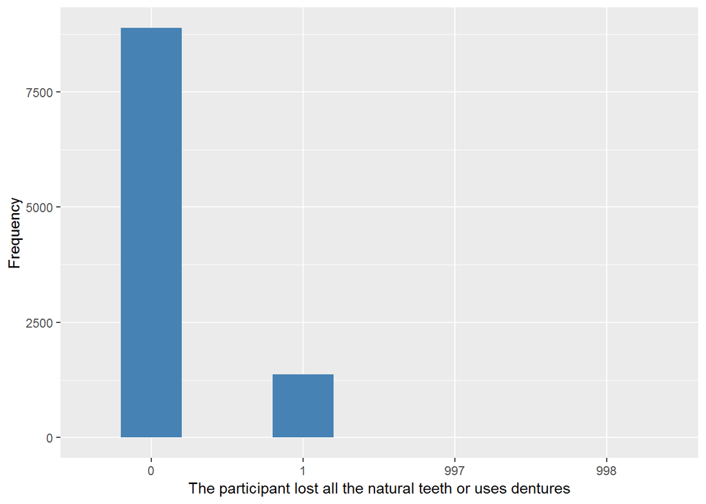

#### 2.1.5.4 Validation

### 2.1.6 Wave 6

Not found.

### 2.1.7 Wave 7

#### 2.1.7.1 Study-specific variable description

| **Name** | `HeDntF` | `HeDntG` |
| --- | --- | --- |
| **Label** | `Whether dentures in upper jaw` | `Whether dentures in lower jaw` |
| **Table name** | `wave_7_elsa_data` | `wave_7_elsa_data` |
| **Categories** | `1 = Yes` `2 = No` | `1 = Yes` `2 = No` |
| **Missings** | `-1 = Not applicable` `-2 = Schedule not applicable` `-8 = Don't Know` `-9 = Refusal` | `-1 = Not applicable` `-2 = Schedule not applicable` `-8 = Don't Know` `-9 = Refusal` |
| **Description** |  |  |

HeDntF

| Sample size | Missing values |
| --- | --- |
| 9666 | 8 |

Category

|  | 1 | 2 |
| --- | --- | --- |
| Frequency | 3046.00 | 6612.0 |
| Percentage | 31.51 | 68.4 |

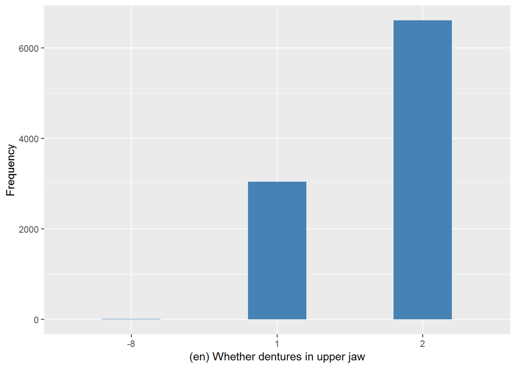

HeDntG

| Sample size | Missing values |
| --- | --- |
| 9666 | 9 |

Category

|  | 1 | 2 |
| --- | --- | --- |
| Frequency | 1849.00 | 7808.00 |
| Percentage | 19.13 | 80.78 |

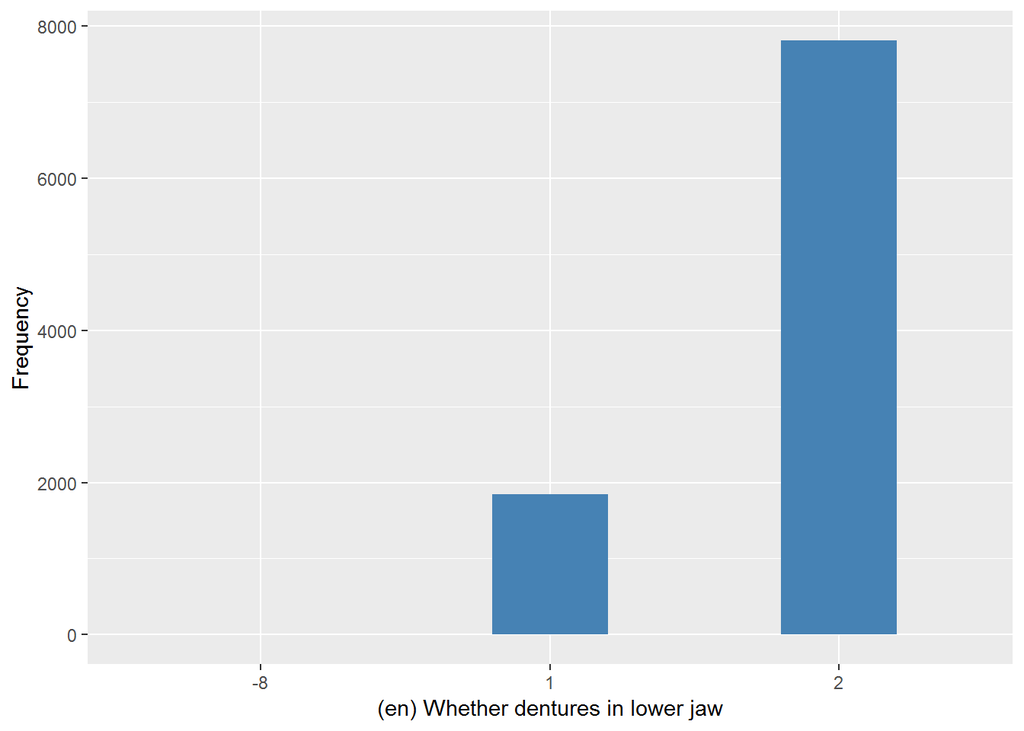

#### 2.1.7.2 Harmonisation algorithm

To compute `oral_problems` from the study-specific variables, they have to be recoded as follows:

- `all 1 into 1`
- `some 2 into 0`
- `-9 into 997`
- `-8 into 998`
- `-1,-2 into 996`

**R script:**

```r
ELSA_ds_w7 <- tibble(id = ELSA_w7$id)
ELSA_ds_w7$oral_problems <- 999
ELSA_ds_w7$oral_problems[which(ELSA_w7$HeDntF == -9 | ELSA_w7$HeDntG == -9)] <- 997
ELSA_ds_w7$oral_problems[which(ELSA_w7$HeDntF == -8 | ELSA_w7$HeDntG == -8)] <- 998
ELSA_ds_w7$oral_problems[which(ELSA_w7$HeDntF %in% c(-1, -2) | ELSA_w7$HeDntG %in%
    c(-1, -2))] <- 996
ELSA_ds_w7$oral_problems[which(ELSA_w7$HeDntF == 2 | ELSA_w7$HeDntG == 2)] <- 0
ELSA_ds_w7$oral_problems[which(ELSA_w7$HeDntF == 1 & ELSA_w7$HeDntG == 1)] <- 1
```

#### 2.1.7.3 Statistical description of the new harmonised variable

The participant lost all the natural teeth or uses dentures

| Sample size | Missing values |
| --- | --- |
| 9666 | 9 |

Category

|  | 0 | 1 |
| --- | --- | --- |
| Frequency | 8006.00 | 1651.00 |
| Percentage | 82.83 | 17.08 |

Type of missing

|  | 991 | 992 | 993 | 994 | 995 | 996 | 997 | 998 | 999 | NA |
| --- | --- | --- | --- | --- | --- | --- | --- | --- | --- | --- |
| Frequency | 0 | 0 | 0 | 0 | 0 | 0 | 0 | 9.00 | 0 | 0 |
| Percentage | 0 | 0 | 0 | 0 | 0 | 0 | 0 | 0.09 | 0 | 0 |

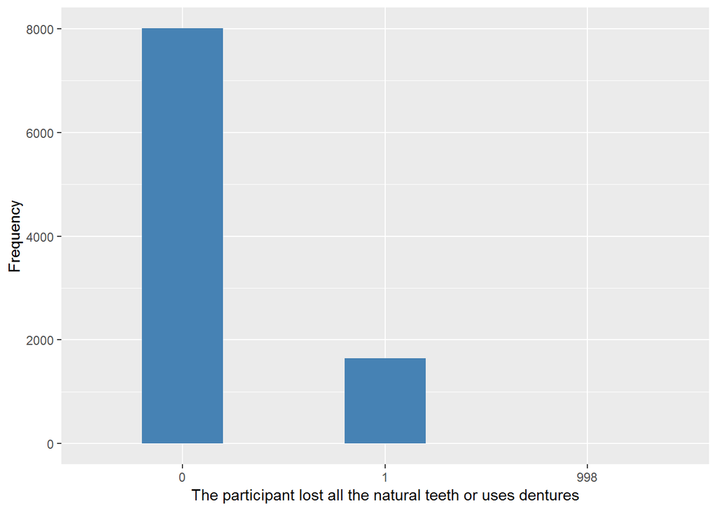

#### 2.1.7.4 Validation

## 2.2 Summary of descriptive statistics of the harmonised variable accross populations and waves

Two tables are generated:

1. Percentages of categories in each harmonised variable.
2. Frequencies and percentages of individuals with different trajectories.

The participant lost all the natural teeth or uses dentures

| val | label | W3 | W5 | W7 |
| --- | --- | --- | --- | --- |
| 0 | No | 83.95 | 86.5 | 82.83 |
| 1 | Yes | 15.99 | 13.39 | 17.08 |
| 991 | CAPI interviewer error | 0 | 0 | 0 |
| 992 | Impute | 0 | 0 | 0 |
| 993 | Disable to measure | 0 | 0 | 0 |
| 994 | Not attempt not done | 0 | 0 | 0 |
| 995 | Does not answer | 0 | 0 | 0 |
| 996 | Not applicable | 0 | 0 | 0 |
| 997 | Refuse | 0.02 | 0.06 | 0 |
| 998 | Do not know | 0.04 | 0.05 | 0.09 |
| 999 | Missing | 0 | 0 | 0 |
| NA | NA | 0 | 0 | 0 |
| n | sample size | 9771 | 10274 | 9666 |

| val | frq | raw.prc |
| --- | --- | --- |
| 000 | 4418 | 30.90 |
| 001 | 544 | 3.81 |
| 00NA | 1241 | 8.68 |
| 010 | 54 | 0.38 |
| 011 | 58 | 0.41 |
| 01NA | 60 | 0.42 |
| 0NA0 | 134 | 0.94 |
| 0NA1 | 25 | 0.17 |
| 0NANA | 1669 | 11.67 |
| 100 | 37 | 0.26 |
| 101 | 30 | 0.21 |
| 10NA | 27 | 0.19 |
| 110 | 31 | 0.22 |
| 111 | 525 | 3.67 |
| 11NA | 318 | 2.22 |
| 1NA0 | 1 | 0.01 |
| 1NA1 | 21 | 0.15 |
| 1NANA | 572 | 4.00 |
| NA00 | 1786 | 12.49 |
| NA01 | 174 | 1.22 |
| NA0NA | 630 | 4.41 |
| NA10 | 43 | 0.30 |
| NA11 | 175 | 1.22 |
| NA1NA | 112 | 0.78 |
| NANA0 | 1502 | 10.51 |
| NANA1 | 99 | 0.69 |
| NANANA | 10 | 0.07 |
| NA | 0 | 0.00 |

# 3 Quality estimation